# union_intersect_subtract

## union_intersect_subtract

#### Question

1. To answer this question, open a [new SketchUp](https://app.sketchup.com) with *Decimal - Meters* as your units. In this problem, assume all lengths are in meters and all volumes are in cubic meters.
   - Generate a rectangular prism, with $w=5.1$, $d=9.8$, and $h=9.3$, with a corner on the origin:
     - Draw a rectangle with one corner on the origin. Dimensions: 5.1 by 9.8. Make sure the rectangle will pull up along the blue axis.
     - Pull the rectangle up by 9.3 meters (in direction of blue axis).
     - Triple click the object to highlight everything.
     - Right click and Make Group.
   - Generate a cylinder with radius $r=4.4$ and height $h=15.1$ so that the bottom face’s center is at the origin.
     - Draw a circle with radius $4.4$ with its center at the origin. Make sure the circle will pull up along the blue axis.
     - Pull the circle up by 15.1 meters (in direction of blue axis).
     - Triple click the object to highlight everything.
     - Right click and Make Group.

   We will practice using the `Union`, `Intersection`, and `Subtract` functions in SketchUp. To find the volume of an object, click on it and then open the `Entity Info` (button is top-right of window). The volume will be shown there.

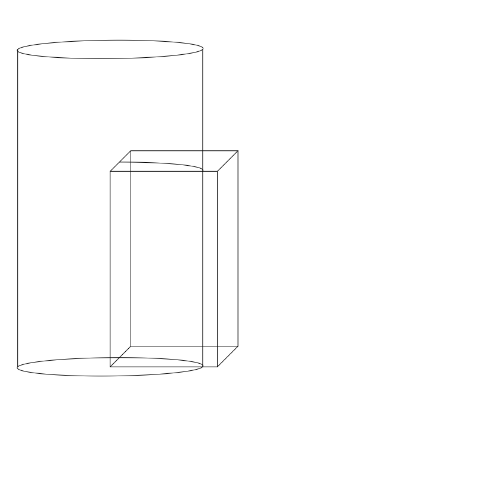

   - What is the volume of the rectangular prism?
   - $\mathrm{m^3}$
   - What is the volume of the cylinder?
   - $\mathrm{m^3}$
   - What is the volume of the union between the prism and the cylinder?
   - $\mathrm{m^3}$
   - What is the volume of the intersection between the prism and the cylinder?
   - $\mathrm{m^3}$
   - What is the volume of the subtraction of the cylinder from prism? (click cylinder then prism)
   - $\mathrm{m^3}$
   - What is the volume of the subtraction of the prism from cylinder? (click prism then cylinder)
   - $\mathrm{m^3}$

#### Question

2. To answer this question, open a [new SketchUp](https://app.sketchup.com) with *Decimal - Meters* as your units. In this problem, assume all lengths are in meters and all volumes are in cubic meters.
   - Generate a rectangular prism, with $w=5.4$, $d=5.8$, and $h=8.4$, with a corner on the origin:
     - Draw a rectangle with one corner on the origin. Dimensions: 5.4 by 5.8. Make sure the rectangle will pull up along the blue axis.
     - Pull the rectangle up by 8.4 meters (in direction of blue axis).
     - Triple click the object to highlight everything.
     - Right click and Make Group.
   - Generate a cylinder with radius $r=3.5$ and height $h=16$ so that the bottom face’s center is at the origin.
     - Draw a circle with radius $3.5$ with its center at the origin. Make sure the circle will pull up along the blue axis.
     - Pull the circle up by 16 meters (in direction of blue axis).
     - Triple click the object to highlight everything.
     - Right click and Make Group.

   We will practice using the `Union`, `Intersection`, and `Subtract` functions in SketchUp. To find the volume of an object, click on it and then open the `Entity Info` (button is top-right of window). The volume will be shown there.

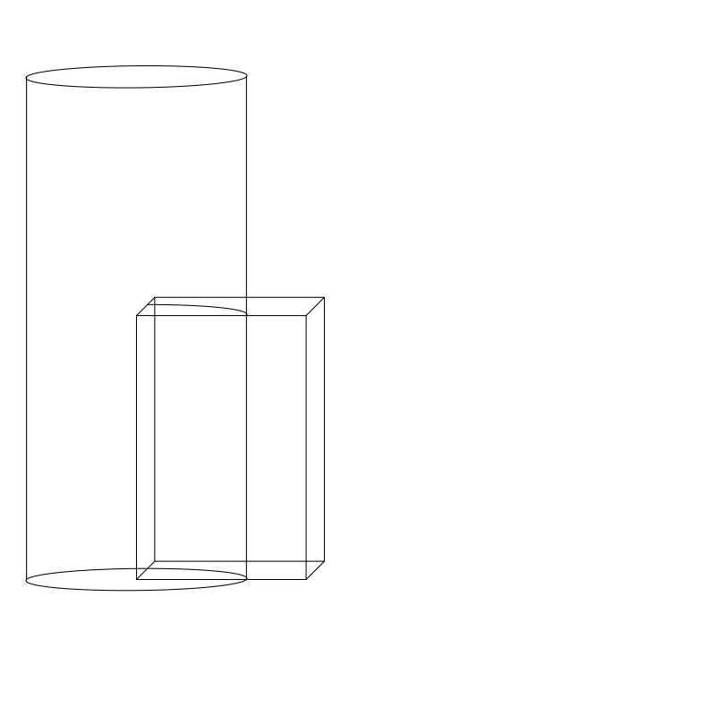

   - What is the volume of the rectangular prism?
   - $\mathrm{m^3}$
   - What is the volume of the cylinder?
   - $\mathrm{m^3}$
   - What is the volume of the union between the prism and the cylinder?
   - $\mathrm{m^3}$
   - What is the volume of the intersection between the prism and the cylinder?
   - $\mathrm{m^3}$
   - What is the volume of the subtraction of the cylinder from prism? (click cylinder then prism)
   - $\mathrm{m^3}$
   - What is the volume of the subtraction of the prism from cylinder? (click prism then cylinder)
   - $\mathrm{m^3}$

#### Question

3. To answer this question, open a [new SketchUp](https://app.sketchup.com) with *Decimal - Meters* as your units. In this problem, assume all lengths are in meters and all volumes are in cubic meters.
   - Generate a rectangular prism, with $w=9.7$, $d=6.2$, and $h=8.7$, with a corner on the origin:
     - Draw a rectangle with one corner on the origin. Dimensions: 9.7 by 6.2. Make sure the rectangle will pull up along the blue axis.
     - Pull the rectangle up by 8.7 meters (in direction of blue axis).
     - Triple click the object to highlight everything.
     - Right click and Make Group.
   - Generate a cylinder with radius $r=5.3$ and height $h=10.6$ so that the bottom face’s center is at the origin.
     - Draw a circle with radius $5.3$ with its center at the origin. Make sure the circle will pull up along the blue axis.
     - Pull the circle up by 10.6 meters (in direction of blue axis).
     - Triple click the object to highlight everything.
     - Right click and Make Group.

   We will practice using the `Union`, `Intersection`, and `Subtract` functions in SketchUp. To find the volume of an object, click on it and then open the `Entity Info` (button is top-right of window). The volume will be shown there.

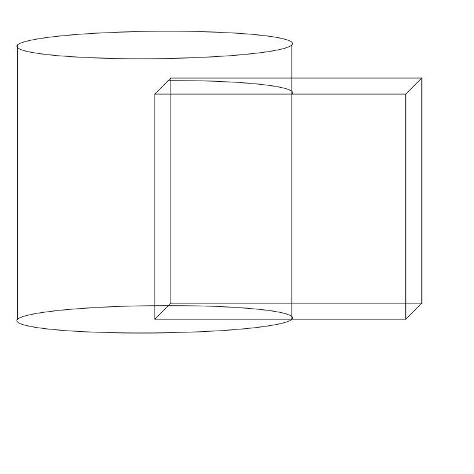

   - What is the volume of the rectangular prism?
   - $\mathrm{m^3}$
   - What is the volume of the cylinder?
   - $\mathrm{m^3}$
   - What is the volume of the union between the prism and the cylinder?
   - $\mathrm{m^3}$
   - What is the volume of the intersection between the prism and the cylinder?
   - $\mathrm{m^3}$
   - What is the volume of the subtraction of the cylinder from prism? (click cylinder then prism)
   - $\mathrm{m^3}$
   - What is the volume of the subtraction of the prism from cylinder? (click prism then cylinder)
   - $\mathrm{m^3}$

#### Question

4. To answer this question, open a [new SketchUp](https://app.sketchup.com) with *Decimal - Meters* as your units. In this problem, assume all lengths are in meters and all volumes are in cubic meters.
   - Generate a rectangular prism, with $w=4.2$, $d=5.1$, and $h=8.4$, with a corner on the origin:
     - Draw a rectangle with one corner on the origin. Dimensions: 4.2 by 5.1. Make sure the rectangle will pull up along the blue axis.
     - Pull the rectangle up by 8.4 meters (in direction of blue axis).
     - Triple click the object to highlight everything.
     - Right click and Make Group.
   - Generate a cylinder with radius $r=3.9$ and height $h=8.7$ so that the bottom face’s center is at the origin.
     - Draw a circle with radius $3.9$ with its center at the origin. Make sure the circle will pull up along the blue axis.
     - Pull the circle up by 8.7 meters (in direction of blue axis).
     - Triple click the object to highlight everything.
     - Right click and Make Group.

   We will practice using the `Union`, `Intersection`, and `Subtract` functions in SketchUp. To find the volume of an object, click on it and then open the `Entity Info` (button is top-right of window). The volume will be shown there.

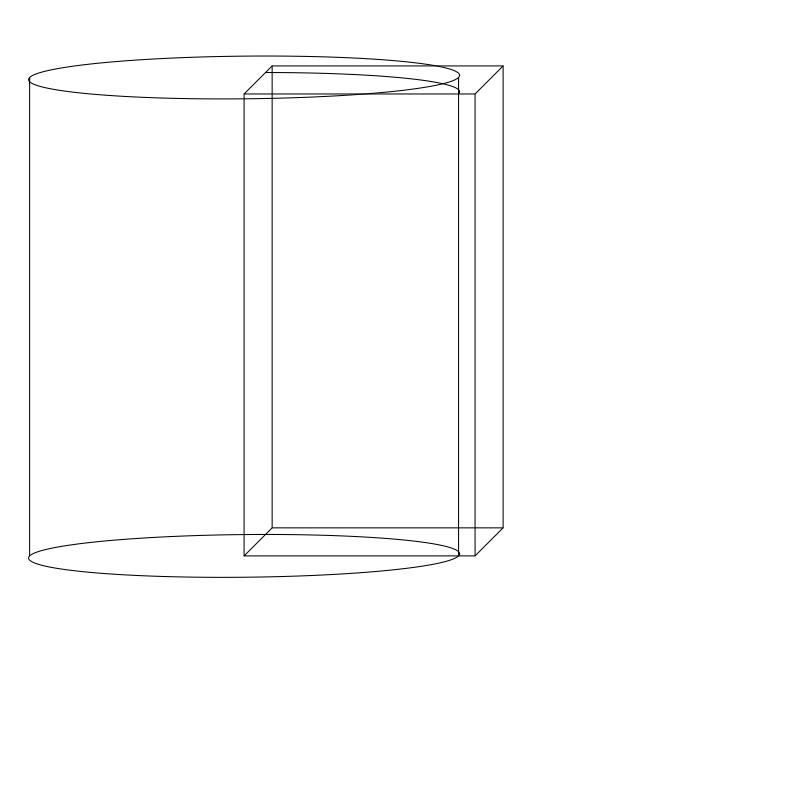

   - What is the volume of the rectangular prism?
   - $\mathrm{m^3}$
   - What is the volume of the cylinder?
   - $\mathrm{m^3}$
   - What is the volume of the union between the prism and the cylinder?
   - $\mathrm{m^3}$
   - What is the volume of the intersection between the prism and the cylinder?
   - $\mathrm{m^3}$
   - What is the volume of the subtraction of the cylinder from prism? (click cylinder then prism)
   - $\mathrm{m^3}$
   - What is the volume of the subtraction of the prism from cylinder? (click prism then cylinder)
   - $\mathrm{m^3}$

#### Question

5. To answer this question, open a [new SketchUp](https://app.sketchup.com) with *Decimal - Meters* as your units. In this problem, assume all lengths are in meters and all volumes are in cubic meters.
   - Generate a rectangular prism, with $w=4.5$, $d=8.6$, and $h=5.5$, with a corner on the origin:
     - Draw a rectangle with one corner on the origin. Dimensions: 4.5 by 8.6. Make sure the rectangle will pull up along the blue axis.
     - Pull the rectangle up by 5.5 meters (in direction of blue axis).
     - Triple click the object to highlight everything.
     - Right click and Make Group.
   - Generate a cylinder with radius $r=3.9$ and height $h=9$ so that the bottom face’s center is at the origin.
     - Draw a circle with radius $3.9$ with its center at the origin. Make sure the circle will pull up along the blue axis.
     - Pull the circle up by 9 meters (in direction of blue axis).
     - Triple click the object to highlight everything.
     - Right click and Make Group.

   We will practice using the `Union`, `Intersection`, and `Subtract` functions in SketchUp. To find the volume of an object, click on it and then open the `Entity Info` (button is top-right of window). The volume will be shown there.

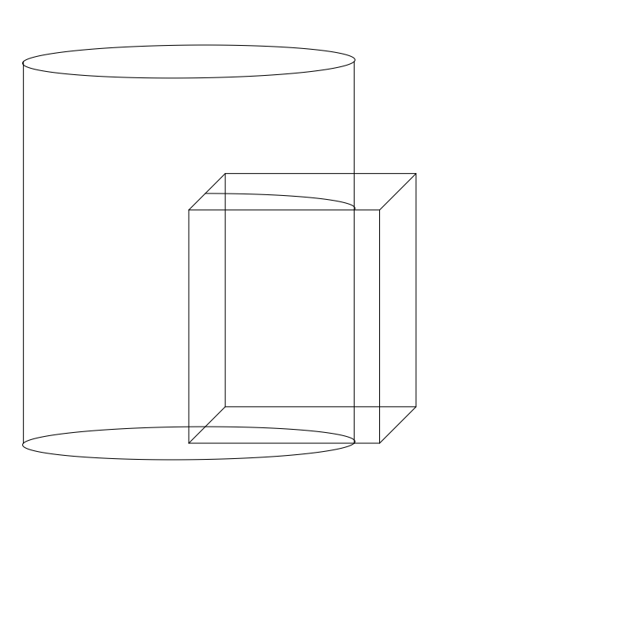

   - What is the volume of the rectangular prism?
   - $\mathrm{m^3}$
   - What is the volume of the cylinder?
   - $\mathrm{m^3}$
   - What is the volume of the union between the prism and the cylinder?
   - $\mathrm{m^3}$
   - What is the volume of the intersection between the prism and the cylinder?
   - $\mathrm{m^3}$
   - What is the volume of the subtraction of the cylinder from prism? (click cylinder then prism)
   - $\mathrm{m^3}$
   - What is the volume of the subtraction of the prism from cylinder? (click prism then cylinder)
   - $\mathrm{m^3}$

#### Question

6. To answer this question, open a [new SketchUp](https://app.sketchup.com) with *Decimal - Meters* as your units. In this problem, assume all lengths are in meters and all volumes are in cubic meters.
   - Generate a rectangular prism, with $w=7.1$, $d=8.5$, and $h=9.1$, with a corner on the origin:
     - Draw a rectangle with one corner on the origin. Dimensions: 7.1 by 8.5. Make sure the rectangle will pull up along the blue axis.
     - Pull the rectangle up by 9.1 meters (in direction of blue axis).
     - Triple click the object to highlight everything.
     - Right click and Make Group.
   - Generate a cylinder with radius $r=3.5$ and height $h=7.5$ so that the bottom face’s center is at the origin.
     - Draw a circle with radius $3.5$ with its center at the origin. Make sure the circle will pull up along the blue axis.
     - Pull the circle up by 7.5 meters (in direction of blue axis).
     - Triple click the object to highlight everything.
     - Right click and Make Group.

   We will practice using the `Union`, `Intersection`, and `Subtract` functions in SketchUp. To find the volume of an object, click on it and then open the `Entity Info` (button is top-right of window). The volume will be shown there.

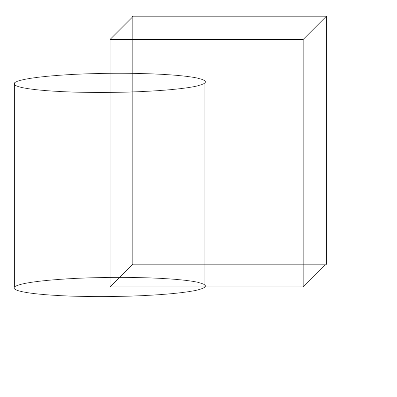

   - What is the volume of the rectangular prism?
   - $\mathrm{m^3}$
   - What is the volume of the cylinder?
   - $\mathrm{m^3}$
   - What is the volume of the union between the prism and the cylinder?
   - $\mathrm{m^3}$
   - What is the volume of the intersection between the prism and the cylinder?
   - $\mathrm{m^3}$
   - What is the volume of the subtraction of the cylinder from prism? (click cylinder then prism)
   - $\mathrm{m^3}$
   - What is the volume of the subtraction of the prism from cylinder? (click prism then cylinder)
   - $\mathrm{m^3}$

#### Question

7. To answer this question, open a [new SketchUp](https://app.sketchup.com) with *Decimal - Meters* as your units. In this problem, assume all lengths are in meters and all volumes are in cubic meters.
   - Generate a rectangular prism, with $w=5.8$, $d=8.8$, and $h=9.4$, with a corner on the origin:
     - Draw a rectangle with one corner on the origin. Dimensions: 5.8 by 8.8. Make sure the rectangle will pull up along the blue axis.
     - Pull the rectangle up by 9.4 meters (in direction of blue axis).
     - Triple click the object to highlight everything.
     - Right click and Make Group.
   - Generate a cylinder with radius $r=4.4$ and height $h=7.2$ so that the bottom face’s center is at the origin.
     - Draw a circle with radius $4.4$ with its center at the origin. Make sure the circle will pull up along the blue axis.
     - Pull the circle up by 7.2 meters (in direction of blue axis).
     - Triple click the object to highlight everything.
     - Right click and Make Group.

   We will practice using the `Union`, `Intersection`, and `Subtract` functions in SketchUp. To find the volume of an object, click on it and then open the `Entity Info` (button is top-right of window). The volume will be shown there.

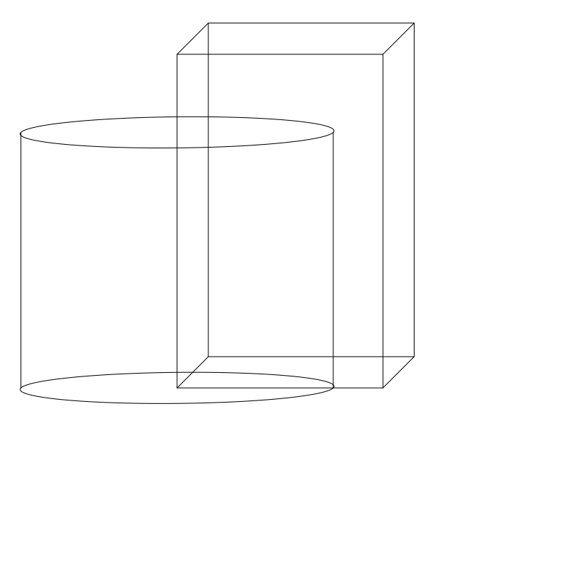

   - What is the volume of the rectangular prism?
   - $\mathrm{m^3}$
   - What is the volume of the cylinder?
   - $\mathrm{m^3}$
   - What is the volume of the union between the prism and the cylinder?
   - $\mathrm{m^3}$
   - What is the volume of the intersection between the prism and the cylinder?
   - $\mathrm{m^3}$
   - What is the volume of the subtraction of the cylinder from prism? (click cylinder then prism)
   - $\mathrm{m^3}$
   - What is the volume of the subtraction of the prism from cylinder? (click prism then cylinder)
   - $\mathrm{m^3}$

#### Question

8. To answer this question, open a [new SketchUp](https://app.sketchup.com) with *Decimal - Meters* as your units. In this problem, assume all lengths are in meters and all volumes are in cubic meters.
   - Generate a rectangular prism, with $w=6.7$, $d=7$, and $h=8.6$, with a corner on the origin:
     - Draw a rectangle with one corner on the origin. Dimensions: 6.7 by 7. Make sure the rectangle will pull up along the blue axis.
     - Pull the rectangle up by 8.6 meters (in direction of blue axis).
     - Triple click the object to highlight everything.
     - Right click and Make Group.
   - Generate a cylinder with radius $r=5.2$ and height $h=14$ so that the bottom face’s center is at the origin.
     - Draw a circle with radius $5.2$ with its center at the origin. Make sure the circle will pull up along the blue axis.
     - Pull the circle up by 14 meters (in direction of blue axis).
     - Triple click the object to highlight everything.
     - Right click and Make Group.

   We will practice using the `Union`, `Intersection`, and `Subtract` functions in SketchUp. To find the volume of an object, click on it and then open the `Entity Info` (button is top-right of window). The volume will be shown there.

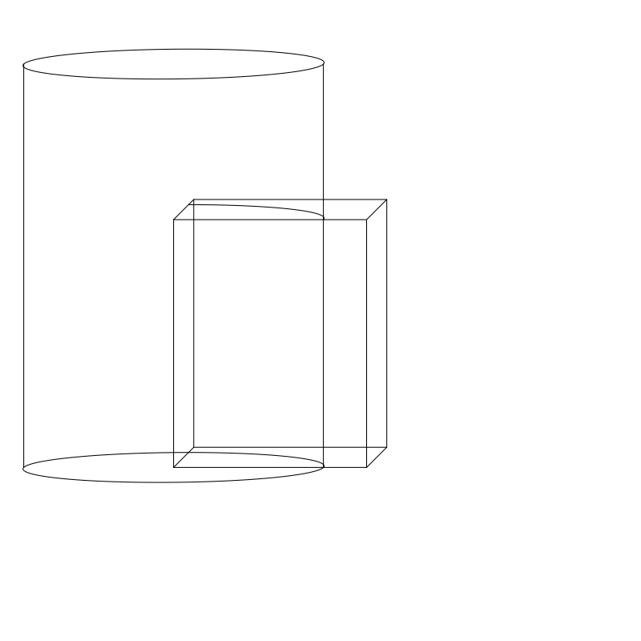

   - What is the volume of the rectangular prism?
   - $\mathrm{m^3}$
   - What is the volume of the cylinder?
   - $\mathrm{m^3}$
   - What is the volume of the union between the prism and the cylinder?
   - $\mathrm{m^3}$
   - What is the volume of the intersection between the prism and the cylinder?
   - $\mathrm{m^3}$
   - What is the volume of the subtraction of the cylinder from prism? (click cylinder then prism)
   - $\mathrm{m^3}$
   - What is the volume of the subtraction of the prism from cylinder? (click prism then cylinder)
   - $\mathrm{m^3}$